# deca_16Spermanova

Dylan Barth

2025-12-31

## Import data

To compute a permanova test with adonis2, we first must load in the distance matrix calculated in the previous step. We also will need the metadata that correlates to the samples, so we pull in the phyloseq object and extract the metadata.

```r
decadist <- readRDS('data/16Svegan/bray.dist.rds')
ps <- readRDS('data/16Sdada2/phyloseq.filtered.rds')
meta <- data.frame(sample_data(ps))
```

## Run adonis2

Adonis2 is a package that implements PERMANOVA on a distance matrix. We utilize the previously created distance matrix here and test the independent variables within Microhabitat, Time, and Treatment for differences in centroids within this structure. While it is useful to check if the means of groups differ, it is also of importance to infer differences of variance which often drive significant results in adonis2.

When running adonis2 using the argument `by='term'` calculates a statistical test in which the order of the variables in the model matters. For that reason, the test is run without interactions two times, forward and backward to account for any discrepancies that come about due to order. We find that regardless of the model order, the same order of importance is assigned to each of the measured variables. In order of their `F-scores` the variables are `Surface_Subsurface` `SampleDate` `Grass_Interspace` and `Treatment`.

Lastly, checking for within-group differences in dispersion allows us to decide whether or not the results in the PERMANOVA test can be interpreted simply. If differences occur in dispersion, the direct effect of differences in mean can be masked. However, differences in dispersion also tell us that two groups behave differently, suggesting it may be simpler to analyze them separately. From this analysis, there’s clearly a distinction between dispersions of surface depth and sample date, possibly for treatment, and no difference between grass and interspace conditions.

```r
print('Forwards Model')
```

```
## [1] "Forwards Model"
```

```r
fulltest <- adonis2(formula = decadist ~ Treatment+SampleDate+Grass_Interspace+Surface_Subsurface,
                    data=meta, by='term', permutations=1e5, parallel=12, na.action = na.omit)
print(fulltest)
```

```
## Permutation test for adonis under reduced model
## Terms added sequentially (first to last)
## Permutation: free
## Number of permutations: 1e+05
##
## adonis2(formula = decadist ~ Treatment + SampleDate + Grass_Interspace + Surface_Subsurface, data = meta, permutations = 1e+05, by = "term", parallel = 12, na.action = na.omit)
##                     Df SumOfSqs      R2        F Pr(>F)
## Treatment            8    7.376 0.02596   4.1718  1e-05 ***
## SampleDate           5   15.644 0.05507  14.1575  1e-05 ***
## Grass_Interspace     1    2.689 0.00946  12.1665  1e-05 ***
## Surface_Subsurface   1   57.037 0.20078 258.0926  1e-05 ***
## Residual           911  201.326 0.70872
## Total              926  284.071 1.00000
## ---
## Signif. codes:  0 '***' 0.001 '**' 0.01 '*' 0.05 '.' 0.1 ' ' 1
```

```r
print('Backwards Model')
```

```
## [1] "Backwards Model"
```

```r
backwards <- adonis2(formula = decadist ~ Surface_Subsurface+Grass_Interspace+SampleDate+Treatment,
                                 data=meta, by='term', permutations=1e5, parallel=12, na.action = na.omit)
print(backwards)
```

```
## Permutation test for adonis under reduced model
## Terms added sequentially (first to last)
## Permutation: free
## Number of permutations: 1e+05
##
## adonis2(formula = decadist ~ Surface_Subsurface + Grass_Interspace + SampleDate + Treatment, data = meta, permutations = 1e+05, by = "term", parallel = 12, na.action = na.omit)
##                     Df SumOfSqs      R2        F Pr(>F)
## Surface_Subsurface   1   57.230 0.20146 258.9662  1e-05 ***
## Grass_Interspace     1    2.508 0.00883  11.3470  1e-05 ***
## SampleDate           6   16.592 0.05841  12.5132  1e-05 ***
## Treatment            7    6.415 0.02258   4.1469  1e-05 ***
## Residual           911  201.326 0.70872
## Total              926  284.071 1.00000
## ---
## Signif. codes:  0 '***' 0.001 '**' 0.01 '*' 0.05 '.' 0.1 ' ' 1
```

```r
print('Dispersion of Treatment')
```

```
## [1] "Dispersion of Treatment"
```

```r
disptreat <- betadisper(decadist, group=meta$Treatment)
permutest(disptreat, permutations = 1e4)
```

```
##
## Permutation test for homogeneity of multivariate dispersions
## Permutation: free
## Number of permutations: 10000
##
## Response: Distances
##            Df Sum Sq   Mean Sq      F N.Perm Pr(>F)
## Groups      8 0.1062 0.0132709 3.1521  10000 0.0013 **
## Residuals 918 3.8649 0.0042101
## ---
## Signif. codes:  0 '***' 0.001 '**' 0.01 '*' 0.05 '.' 0.1 ' ' 1
```

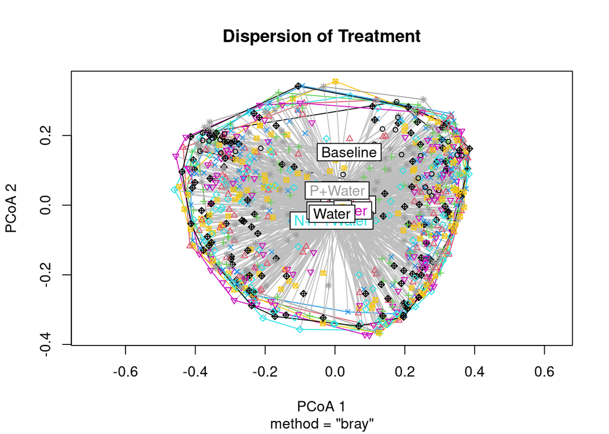

```r
plot(disptreat, main = 'Dispersion of Treatment')
```

```r
print('Dispersion of Sample Date')
```

```
## [1] "Dispersion of Sample Date"
```

```r
dispdate <- betadisper(decadist, group=meta$SampleDate)
permutest(dispdate, permutations = 1e4)
```

```
##
## Permutation test for homogeneity of multivariate dispersions
## Permutation: free
## Number of permutations: 10000
##
## Response: Distances
##            Df Sum Sq  Mean Sq      F N.Perm    Pr(>F)
## Groups      6 0.3923 0.065385 18.053  10000 9.999e-05 ***
## Residuals 920 3.3321 0.003622
## ---
## Signif. codes:  0 '***' 0.001 '**' 0.01 '*' 0.05 '.' 0.1 ' ' 1
```

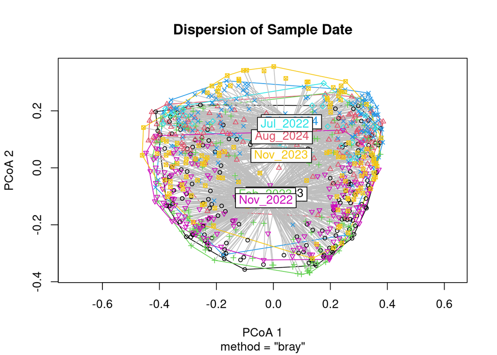

```r
plot(dispdate, main = 'Dispersion of Sample Date')
```

```r
print('Dispersion of Grass/Interspace')
```

```
## [1] "Dispersion of Grass/Interspace"
```

```r
dispgi <- betadisper(decadist, group=meta$Grass_Interspace)
permutest(dispgi, permutations = 1e4)
```

```
##
## Permutation test for homogeneity of multivariate dispersions
## Permutation: free
## Number of permutations: 10000
##
## Response: Distances
##            Df Sum Sq   Mean Sq      F N.Perm Pr(>F)
## Groups      1 0.0081 0.0081469 1.9761  10000  0.161
## Residuals 925 3.8135 0.0041227
```

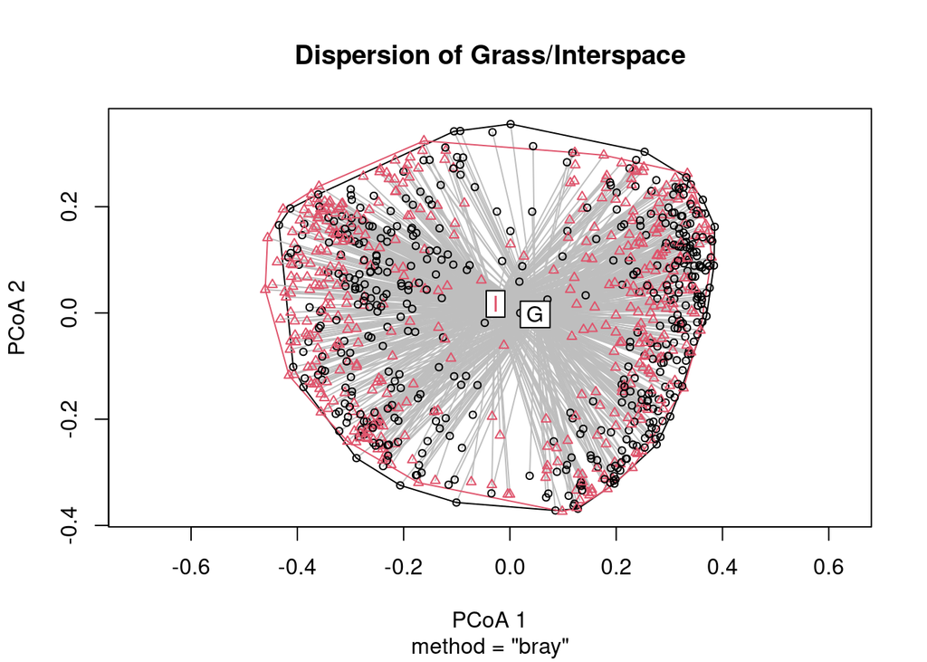

```r
plot(dispgi, main = 'Dispersion of Grass/Interspace')
```

```r
print('Dispersion of Surface/Subsurface')
```

```
## [1] "Dispersion of Surface/Subsurface"
```

```r
dispss <- betadisper(decadist, group=meta$Surface_Subsurface)
permutest(dispss, permutations = 1e4)
```

```
##
## Permutation test for homogeneity of multivariate dispersions
## Permutation: free
## Number of permutations: 10000
##
## Response: Distances
##            Df Sum Sq  Mean Sq      F N.Perm    Pr(>F)
## Groups      1 0.1379 0.137938 18.329  10000 9.999e-05 ***
## Residuals 925 6.9612 0.007526
## ---
## Signif. codes:  0 '***' 0.001 '**' 0.01 '*' 0.05 '.' 0.1 ' ' 1
```

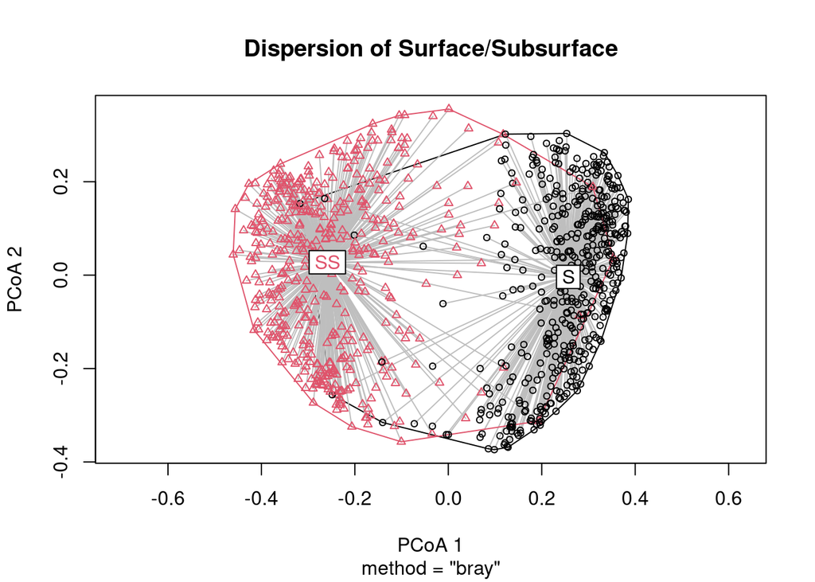

```r
plot(dispss, main = 'Dispersion of Surface/Subsurface')
```